# Classification through Probabilistic Learning: Stellar Classification

### fiber_ID

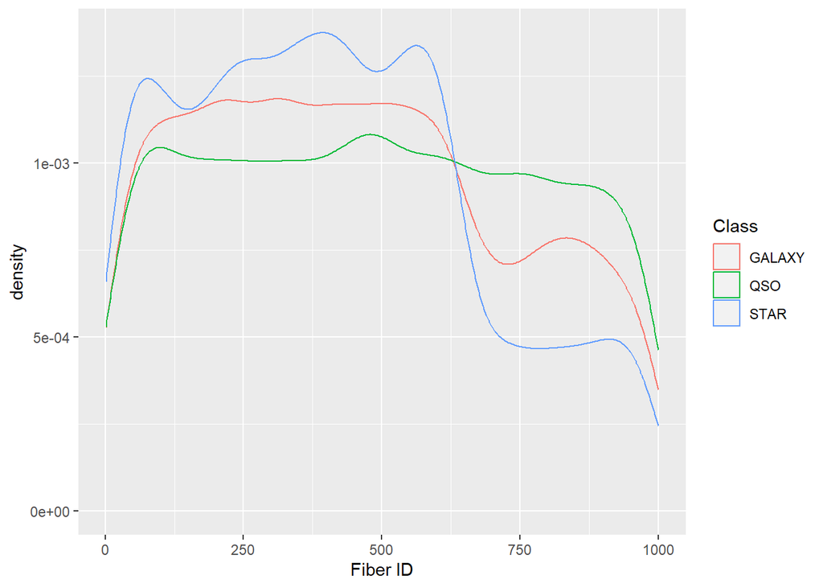

```r
ggplot(data_train, aes(x=fiber_ID, color=Class)) +
  geom_density() +
  labs(x="Fiber ID")
```

## 2.3 Correlation and collinearity

Once all the variables have been individually studied more in depth and before starting with the creation of models, it is convenient to check one last thing: correlation between variables. Very high correlation between variables might indicate that there is some redundancy in the data and it might lead to problems (in the form of singularities) when fitting the models.

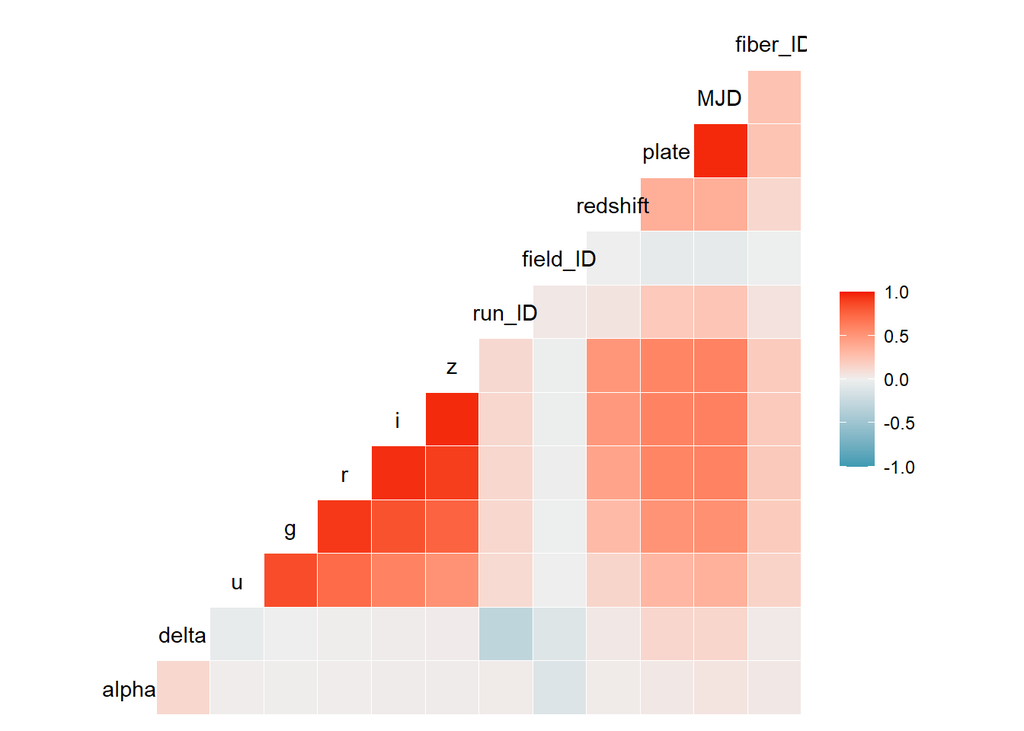

```r
ggcorr(subset(data_train, select=-c(cam_col, Class))) # heatmap of correlations
```

As we can see from the correlations plot, there are several cases of very high correlation: between all the photometric measurements and between `plate` and `MJD`.

```r
# correlation coefficients of variables of interest
cor(subset(data_train, select=c(u,g,r,i,z,plate,MJD)))
```

```
##               u         g         r         i         z     plate       MJD
## u     1.0000000 0.8561520 0.7219644 0.6008635 0.5226948 0.3192989 0.3495598
## g     0.8561520 1.0000000 0.9286294 0.8354445 0.7584261 0.5157824 0.5342678
## r     0.7219644 0.9286294 1.0000000 0.9571140 0.9102771 0.5906566 0.6050742
## i     0.6008635 0.8354445 0.9571140 1.0000000 0.9669712 0.6016845 0.6148576
## z     0.5226948 0.7584261 0.9102771 0.9669712 1.0000000 0.5928490 0.6058943
## plate 0.3192989 0.5157824 0.5906566 0.6016845 0.5928490 1.0000000 0.9700643
## MJD   0.3495598 0.5342678 0.6050742 0.6148576 0.6058943 0.9700643 1.0000000
```

Since removing variables in general is not ideal, we will only remove those variables who present correlation coefficients higher than 0.95 with at least one other variable, that is, `i` and `MJD`.

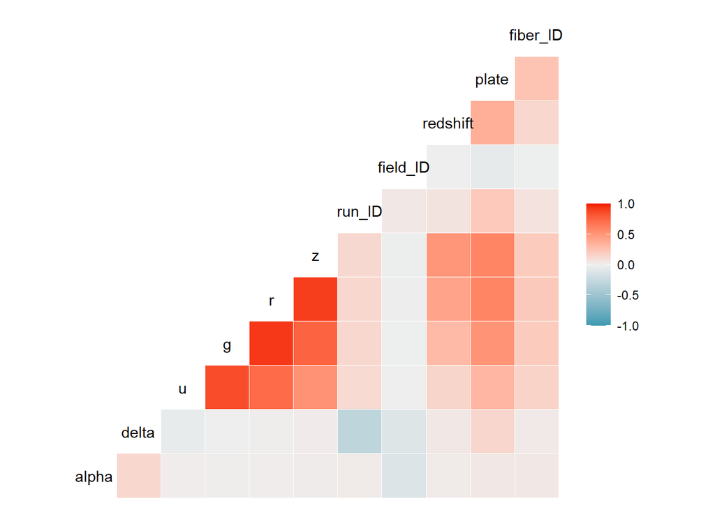

```r
# remove highly correlated variables
data_train = subset(data_train, select=-c(i,MJD))
data_test = subset(data_test, select=-c(i,MJD))
# double-check heatmap of correlations
ggcorr(subset(data_train, select=-c(cam_col, Class)))
```

# 3. Classification

Once the data set has been preprocessed and analysed, we proceed to classification. We are going to classify the test set obtained before with different algorithms. First, several instances of Bayes classifiers will be used, only to compare their performance with that of logistic regression. To better evaluate the models, 5-fold cross-validation will be used to test their performance. As the three classes have been perfectly balanced through downsampling, it is licit to use the accuracy directly as a metric of performance and predictive power.

```r
# prepare crossvalidation
ctrl <- trainControl(method = "repeatedcv",
                     repeats = 1,
                     number = 5)
```

## 3.1 Bayes classifiers

### QDA

First of all, we apply Quadratic Discriminant Analysis (QDA). We first make a model with all the variables:

```r
# train QDA model
qdaFit <- train(Class ~ .,
                method = "qda",
                data = data_train,
                preProcess = c("center", "scale"),
                metric = "Accuracy",
                trControl = ctrl,
                linout=F)

print(qdaFit) # show trained model
```

```
## Quadratic Discriminant Analysis
##
## 28443 samples
##    12 predictor
##     3 classes: 'GALAXY', 'QSO', 'STAR'
##
## Pre-processing: centered (16), scaled (16)
## Resampling: Cross-Validated (5 fold, repeated 1 times)
## Summary of sample sizes: 22755, 22754, 22755, 22754, 22754
## Resampling results:
##
##   Accuracy   Kappa
##   0.9175192  0.8762788
```

```r
qdaPred = predict(qdaFit, data_test) # predict on testing set

confusionMatrix(qdaPred,data_test$Class) # show confusion matrix
```

```
## Confusion Matrix and Statistics
##
##           Reference
## Prediction GALAXY  QSO STAR
##     GALAXY   7898  609  146
##     QSO       546 8817   34
##     STAR     1036   54 9300
##
## Overall Statistics
##
##                Accuracy : 0.9147
##                  95% CI : (0.9114, 0.918)
##     No Information Rate : 0.3333
##     P-Value [Acc > NIR] : < 2.2e-16
##
##                   Kappa : 0.8721
##
##  Mcnemar's Test P-Value : < 2.2e-16
##
## Statistics by Class:
##
##                      Class: GALAXY Class: QSO Class: STAR
## Sensitivity                 0.8331     0.9301      0.9810
## Specificity                 0.9602     0.9694      0.9425
## Pos Pred Value              0.9127     0.9383      0.8951
## Neg Pred Value              0.9200     0.9652      0.9900
## Prevalence                  0.3333     0.3333      0.3333
## Detection Rate              0.2777     0.3100      0.3270
## Detection Prevalence        0.3043     0.3304      0.3653
## Balanced Accuracy           0.8967     0.9497      0.9618
```

With this method, we obtain an accuracy of around 92%, which seems quite high. Although QDA is known to be unstable, the moderately high number of observations in the dataset together with its low dimensionality probably help countering this issue. Furthermore, the accuracy is high considering how sensitive this method is to deviations from a Gaussian distribution in the predictors, such as the ones found in the variables `redshift`, `fiber_ID` or `run_ID`.

Although the accuracy value is high, this is not the only measure that should be watched, as sometimes some misclassifications might lead to more grave errors than others. In this case, it is hard to rank them, which will be discussed more in depth in subsequent sections.

### LDA

We now apply Linear Discriminant Analysis (LDA) in a similar manner to that of QDA. Since one of the assumptions of LDA is that all groups have the same covariance matrix, we specify as an argument to `caret::train()` that the data given as input must be preprocessed by centering and scaling it accordingly. One assumption that LDA shares with QDA is that of the data being Gaussian, for which the predictors have been transformed throughout the previous section, although clear deviations from Gaussianity remain which might affect the results.

```r
# train LDA model on training set
ldaFit <- train(Class ~ .,
                method = "lda",
                data = data_train,
                preProcess = c("center", "scale"),
                metric = "Accuracy",
                trControl = ctrl)

print(ldaFit) # show trained model
```

```
## Linear Discriminant Analysis
##
## 28443 samples
##    12 predictor
##     3 classes: 'GALAXY', 'QSO', 'STAR'
##
## Pre-processing: centered (16), scaled (16)
## Resampling: Cross-Validated (5 fold, repeated 1 times)
## Summary of sample sizes: 22754, 22755, 22755, 22755, 22753
## Resampling results:
##
##   Accuracy   Kappa
##   0.7878916  0.6818373
```

```r
ldaPred = predict(ldaFit, data_test) # predict on testing set

confusionMatrix(ldaPred,data_test$Class) # show confusion matrix
```

```
## Confusion Matrix and Statistics
##
##           Reference
## Prediction GALAXY  QSO STAR
##     GALAXY   6596  418 2022
##     QSO       502 8353   16
##     STAR     2382  709 7442
##
## Overall Statistics
##
##                Accuracy : 0.7873
##                  95% CI : (0.7825, 0.7921)
##     No Information Rate : 0.3333
##     P-Value [Acc > NIR] : < 2.2e-16
##
##                   Kappa : 0.681
##
##  Mcnemar's Test P-Value : < 2.2e-16
##
## Statistics by Class:
##
##                      Class: GALAXY Class: QSO Class: STAR
## Sensitivity                 0.6958     0.8811      0.7850
## Specificity                 0.8713     0.9727      0.8370
## Pos Pred Value              0.7300     0.9416      0.7065
## Neg Pred Value              0.8514     0.9424      0.8862
## Prevalence                  0.3333     0.3333      0.3333
## Detection Rate              0.2319     0.2937      0.2617
## Detection Prevalence        0.3177     0.3119      0.3704
## Balanced Accuracy           0.7835     0.9269      0.8110
```

With this method, the classification predicted yields an accuracy of around 79%, much lower than that of QDA.

### Naïve Bayes

Next, a Naïve Classifier will be used. This method is well-suited to multi-level classification, such as the case at hand. One of the assumptions of this method is the independence of the predictors, among which, as seen before, there exist some cases of somewhat high correlation.

```r
# train Naïve Bayes model on training set
naiveFit <- train(Class ~ .,
                  method = "naive_bayes",
                  data = data_train,
                  preProcess = c("center", "scale"),
                  metric = "Accuracy",
                  trControl = ctrl)

print(naiveFit) # show trained model
```

```
## Naive Bayes
##
## 28443 samples
##    12 predictor
##     3 classes: 'GALAXY', 'QSO', 'STAR'
##
## Pre-processing: centered (16), scaled (16)
## Resampling: Cross-Validated (5 fold, repeated 1 times)
## Summary of sample sizes: 22754, 22754, 22755, 22755, 22754
## Resampling results across tuning parameters:
##
##   usekernel  Accuracy   Kappa
##   FALSE      0.8118691  0.7178037
##    TRUE      0.8957921  0.8436881
##
## Tuning parameter 'laplace' was held constant at a value of 0
## Tuning
##  parameter 'adjust' was held constant at a value of 1
## Accuracy was used to select the optimal model using the largest value.
## The final values used for the model were laplace = 0, usekernel = TRUE
##  and adjust = 1.
```

```r
naivePred = predict(naiveFit, data_test) # make predictions on testing set

confusionMatrix(naivePred, data_test$Class) # show confusion matrix
```

```
## Confusion Matrix and Statistics
##
##           Reference
## Prediction GALAXY  QSO STAR
##     GALAXY   8040  826   28
##     QSO       648 7936   18
##     STAR      792  718 9434
##
## Overall Statistics
##
##                Accuracy : 0.8935
##                  95% CI : (0.8898, 0.897)
##     No Information Rate : 0.3333
##     P-Value [Acc > NIR] : < 2.2e-16
##
##                   Kappa : 0.8402
##
##  Mcnemar's Test P-Value : < 2.2e-16
##
## Statistics by Class:
##
##                      Class: GALAXY Class: QSO Class: STAR
## Sensitivity                 0.8481     0.8371      0.9951
## Specificity                 0.9550     0.9649      0.9204
## Pos Pred Value              0.9040     0.9226      0.8620
## Neg Pred Value              0.9263     0.9222      0.9974
## Prevalence                  0.3333     0.3333      0.3333
## Detection Rate              0.2827     0.2790      0.3317
## Detection Prevalence        0.3127     0.3025      0.3848
## Balanced Accuracy           0.9015     0.9010      0.9578
```

The Naïve Bayes classifier yields predictions with an accuracy of about 89%, once again quite a lot higher than the LDA model.

## 3.2 Logistic regression

Finally, in a completely different approach, logistic regression will be used to perform the classification. Since there are three orderless different classes, binary logistic regression will not suffice, and multinomial logistic regression will have to be used.

The logistic regression model sometimes fail for categories with many levels, but since we are only considering three different classes this should not be a limitation.

```r
# fit logistic regression model on training data
logiFit <- logiFit <- train(Class ~ .,
                method = "glmnet",
                family = "multinomial",
                data = data_train,
                preProcess = c("center", "scale"),
                metric = "Accuracy",
                trControl = ctrl)
print(logiFit) # show fit model
```

```
## glmnet
##
## 28443 samples
##    12 predictor
##     3 classes: 'GALAXY', 'QSO', 'STAR'
##
## Pre-processing: centered (16), scaled (16)
## Resampling: Cross-Validated (5 fold, repeated 1 times)
## Summary of sample sizes: 22754, 22755, 22754, 22754, 22755
## Resampling results across tuning parameters:
##
##   alpha  lambda        Accuracy   Kappa
##   0.10   0.0007315496  0.9181518  0.8772277
##   0.10   0.0073154960  0.8694932  0.8042397
##   0.10   0.0731549598  0.7828290  0.6742435
##   0.55   0.0007315496  0.9244452  0.8866678
##   0.55   0.0073154960  0.8815523  0.8223284
##   0.55   0.0731549598  0.7918645  0.6877968
##   1.00   0.0007315496  0.9369614  0.9054421
##   1.00   0.0073154960  0.9114016  0.8671023
##   1.00   0.0731549598  0.8173891  0.7260837
##
## Accuracy was used to select the optimal model using the largest value.
## The final values used for the model were alpha = 1 and lambda = 0.0007315496.
```

```r
logiPred = predict(logiFit, newdata=data_test) # make predictions on testing set
confusionMatrix(logiPred, data_test$Class) # show confusion matrix
```

```
## Confusion Matrix and Statistics
##
##           Reference
## Prediction GALAXY  QSO STAR
##     GALAXY   8486  752   24
##     QSO       437 8705   21
##     STAR      557   23 9435
##
## Overall Statistics
##
##                Accuracy : 0.9362
##                  95% CI : (0.9333, 0.939)
##     No Information Rate : 0.3333
##     P-Value [Acc > NIR] : < 2.2e-16
##
##                   Kappa : 0.9043
##
##  Mcnemar's Test P-Value : < 2.2e-16
##
## Statistics by Class:
##
##                      Class: GALAXY Class: QSO Class: STAR
## Sensitivity                 0.8951     0.9182      0.9953
## Specificity                 0.9591     0.9758      0.9694
## Pos Pred Value              0.9162     0.9500      0.9421
## Neg Pred Value              0.9482     0.9598      0.9976
## Prevalence                  0.3333     0.3333      0.3333
## Detection Rate              0.2984     0.3061      0.3318
## Detection Prevalence        0.3257     0.3222      0.3521
## Balanced Accuracy           0.9271     0.9470      0.9823
```

The accuracy achieved with the logistic regression model reaches almost 94%, making the most accurate model used.